# py.101.camp

ch11

190317 2042

# CAMP

[figure not shown]

> 比来时强

## AKA

> All Know All

## 预约

> 闪电分享

## BC

> .db
- [d9088b89](https://gitlab.com/101camp/py/commit/d9088b890c0ff286b21b369f22fd77f19903f21f#note_150969387)
- [fa1a6ed1](https://gitlab.com/101camp/py/commit/fa1a6ed1b8adbc5d9df4438a1f4df71a8ea2491e#note_150370466)

## [fa1a6ed1](https://gitlab.com/101camp/py/commit/fa1a6ed1b8adbc5d9df4438a1f4df71a8ea2491e#note_150370466)

> > @yishu

很久没见的 `BC` 但是值得来分享 Err 体验

## [#190](https://gitlab.com/101camp/py/issues/190#note_149944624)

> @XiaoYanWork

方向误判故事

## [#182](https://gitlab.com/101camp/py/issues/182#note_149956632)

> @adi0229

隐藏的老司机, 分享时区问题的通常检验/应对吧

## [#185](https://gitlab.com/101camp/py/issues/185#note_149731410)

> @OMlalala

`什么是真正程序员` 中译版本?

## [#189](https://gitlab.com/101camp/py/issues/189#note_151126068)

> @doituself

分享模糊的任务分析心得

[figure not shown]

## [80c1c197](https://gitlab.com/101camp/py/commit/80c1c197da00d3ae6fd9989a7f8ca59bf9949cb8#note_151097415)

> @tanchangde

引发隐密老坑的理解

## [#191](https://gitlab.com/101camp/py/issues/191#note_151125587)

> @chenmingio

www.chenming.life

## 嗯哼

[figure not shown]

# `ˈriT͟Həm`

## 节奏

> rhythm

## 习惯

> 8w -> 固化

## d0

> 休整

例蟒/交流/激发/…

## d1

> 破题

规划/解析/窜门/…

## d2

> 探索

方案/方向/办法/…

## d3

> 实践

检验/demo/…

## d4

> 开发

调试/模块/目录/版本/…

## d5

> 发布

测试/部署/数据/…

## d6

> review

文档/产品化/配置/…

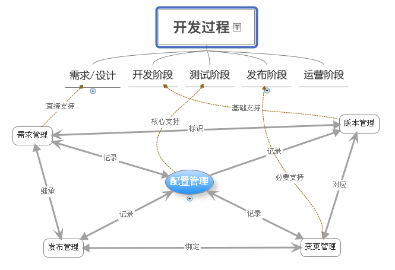

## 分配

> 精力/时间/死线…
- 设计:开发:测试:运营
- 4:1:1:4

## chaos

> 真实世界
- 任何领域都有成堆熟练人士
- 想一切准备好再战?

## 唯快不破

> 慢慢来, 比较快

## 成功

> 是成功者的习惯

## 自信

> 需要如何证明?

## logging

> 一切…

## 依赖?

> 坚持节奏的动力…

## 嗯哼

[figure not shown]

# learnning

[figure not shown]

隐藏大坑

[figure not shown]

正确的画马流程

## Kaopulity

> 靠谱
- **K**eep
- **a**ll
- **o**f
- **p**rocesses
- **u**sabi**lity**

## 依赖?

> 节奏习惯的惯性…

## 以及

> 环境的被动拉动

[自学是门手艺](https://github.com/selfteaching/the-craft-of-selfteaching)

- the-craft-of-selfteaching
  - One has no future if one couldn’t teach themself.

## 嗯哼

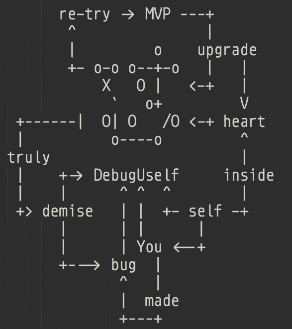

# (￣▽￣)

## [#166](https://gitlab.com/101camp/py/issues/166)

> @chenmingio

[共创]“蟒营是什么?” 文案收集

## [I/O](http://io.101.camp/)

> io.101.camp

## 是也乎

- 190317 DAMA pub.
- 190316 DAMA ++邀请
- 190311 DAMA ++概念故事
- 190310 DAMA init.

## KM

[figure not shown]

知识螺旋

## GFM

> [GitLab Flavored Markdown](https://gitlab.com/help/user/markdown.md)

## 提问

> +5 为什么?

## 5W1H

> 框架…

## [zoom.us](https://zoom.us/download#client_4meeting)

> 例蠎交流
- 周日 2042
- `404-101-4441`
- @huangyu9887 建议统一ID

## VCS

[版本管理](http://s5.zoomquiet.top/080730-cpc-SVN-Trac-KM/index.html)

## 玻璃花园

> C-C 式串门儿

## Activity

- commit
- commit-comments
- issue
- issue-comments
- slack

[figure not shown]

嗯哼

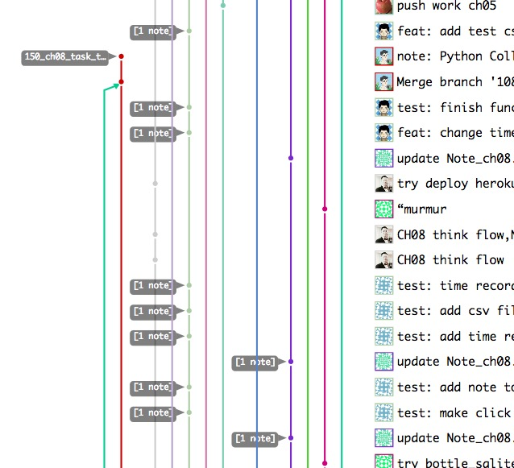

## 新业书

> ~ 转职手册共创
- @chenmingio

[figure not shown]

## IDD

> Issue Drive Develop

## 蠎周刊

> 嗯哼自己..

## 知行

> 合一

[figure not shown]

## pyenv

> Python 本地环境

## virtualenv

> [怎么才能放飞自我的玩儿Python · Yixuan](https://yixuan.li/geek/2018/07/31/pyenvVirtualenv/)

## 如何求助?

> 能技

```
能使
    目标对象
        就
            指定命题
        产生
    科学兴趣的
技术
```

## [提问的智慧](https://github.com/DebugUself/How-To-Ask-Questions-The-Smart-Way/blob/master/README-zh_CN.md)

> 作业?

## WoW

> 不得不赞叹…